# BayesTimeSeriesFull

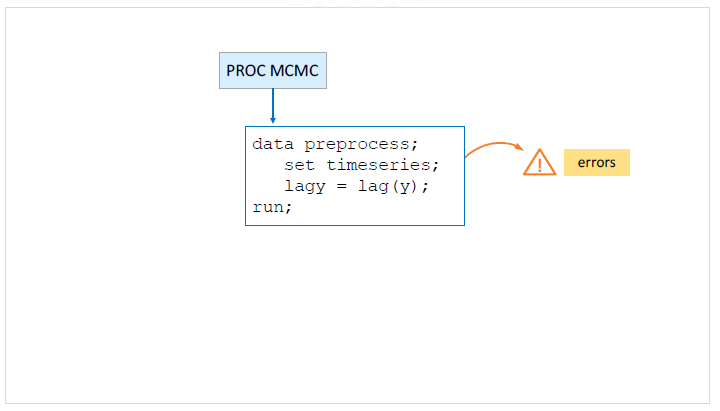

Prior to the execution of the Bayesian code, we will use a DATA step to produce the needed lag terms for the model. PROC MCMC does allow for the use of DATA step procedures within open code to construct the mean element of the model. However, using the lag DATA step function will generate missing values at the start of the series, and these will cause errors in the execution. There are several options of working with lagged values of exogenous variables. Using the external DATA step approach is the most direct. We will talk about this in the demonstration.

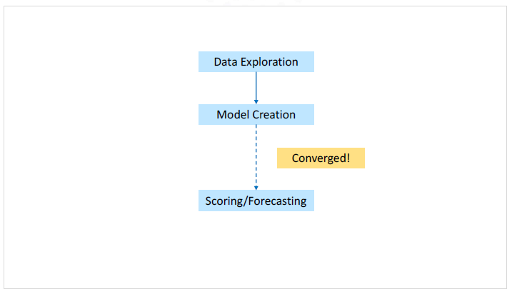

Once you have confirmed that you have a converged solution to your Bayesian analysis, you can then proceed with using this model to create forecasts (scoring). Trying to create forecasts before the solution has converged will waste your time.

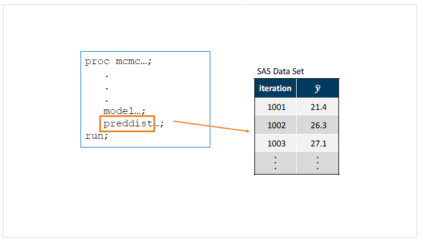

The PREDDIST statement in PROC MCMC is the tool for creating a new SAS data set that contains random samples from the posterior predictive distribution of the response variable, our time series.

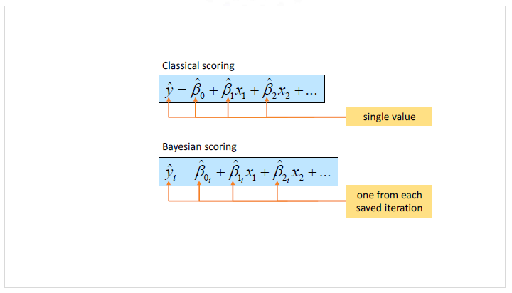

There is a big difference between a classical approach to scoring and a Bayesian approach to scoring. In the classical approach, a single value is estimated for each of the parameters in the model. With the provided observation information and these parameter estimates, we arrive at a single prediction value for the current time point. In the Bayesian approach, this differs because there is no longer a single estimate of the parameter. Recall that we are treating the parameters as random variables and ultimately ending on a posterior distribution for the parameters given the data. It is for this reason that scoring changes in the Bayesian approach.

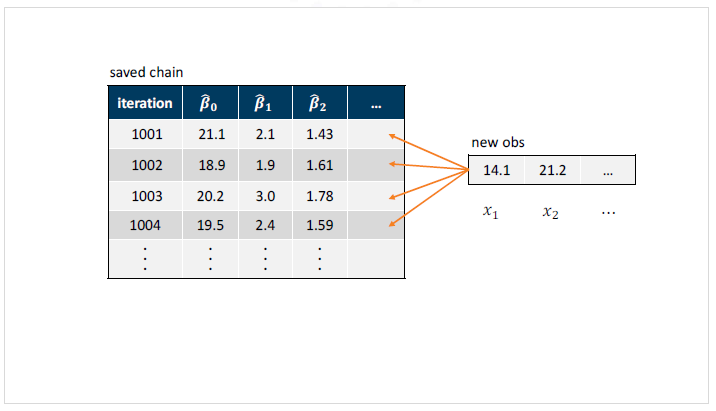

PROC MCMC uses an iterative approach to sample from the posterior distribution of the parameters. At each individual iteration, the current value of the parameter is what, at this moment, we perceive the value of that parameter to be. In the end, we have a chain of iterations saved to represent the sample from the posterior distribution of the parameter. When PREDDIST is active, the values of the observations are combined with each iteration value of the parameters, yielding a predicted response value for each iteration. This chain of predictions creates the sample of the posterior distribution of the prediction at a time point of the series.

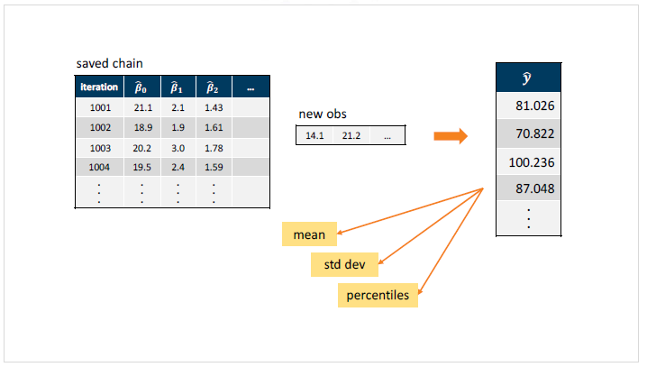

From this posterior sample, we can calculate the mean, standard deviation, and percentiles of that distribution to aid in discussion and presentation.

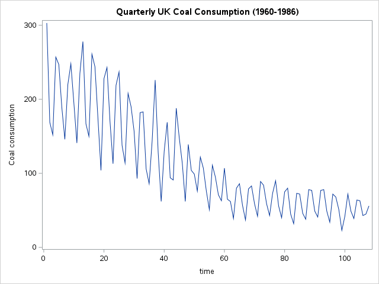

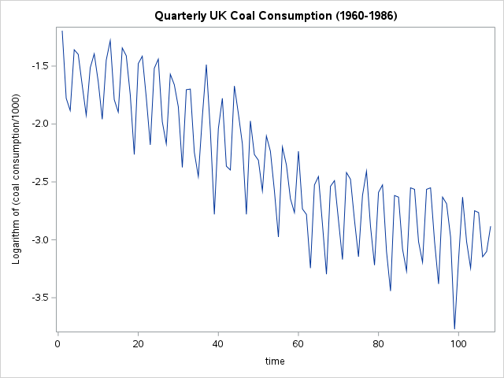

```sas
*Creating Coal Data Example;

data UKcoal;
  input coal year quarter @@;
  t=_N_;
  C=log(coal/1000);
  datalines;
303 1960 1 169 1960 2 152 1960 3 257 1960 4
247 1961 1 189 1961 2 146 1961 3 220 1961 4
248 1962 1 195 1962 2 141 1962 3 235 1962 4
278 1963 1 167 1963 2 150 1963 3 261 1963 4
244 1964 1 174 1964 2 104 1964 3 228 1964 4
243 1965 1 170 1965 2 113 1965 3 219 1965 4
237 1966 1 138 1966 2 114 1966 3 208 1966 4
190 1967 1 157 1967 2 93  1967 3 182 1967 4
183 1968 1 106 1968 2 86  1968 3 144 1968 4
226 1969 1 128 1969 2 62  1969 3 130 1969 4
169 1970 1 94  1970 2 91  1970 3 188 1970 4
148 1971 1 114 1971 2 62  1971 3 139 1971 4
104 1972 1 99  1972 2 76  1972 3 122 1972 4
107 1973 1 76  1973 2 51  1973 3 111 1973 4
95  1974 1 71  1974 2 63  1974 3 107 1974 4
65  1975 1 62  1975 2 39  1975 3 80  1975 4
86  1976 1 57  1976 2 37  1976 3 79  1976 4
83  1977 1 59  1977 2 42  1977 3 89  1977 4
84  1978 1 59  1978 2 43  1978 3 73  1978 4
90  1979 1 56  1979 2 40  1979 3 75  1979 4
80  1980 1 45  1980 2 32  1980 3 73  1980 4
72  1981 1 46  1981 2 38  1981 3 78  1981 4
77  1982 1 49  1982 2 41  1982 3 77  1982 4
78  1983 1 49  1983 2 34  1983 3 72  1983 4
68  1984 1 51  1984 2 23  1984 3 42  1984 4
72  1985 1 49  1985 2 39  1985 3 64  1985 4
63  1986 1 43  1986 2 45  1986 3 56  1986 4
;


proc sgplot data=UKcoal;
  title "Quarterly UK Coal Consumption (1960-1986)";
  series y=coal x=t;
  yaxis label="Coal consumption";
  xaxis label="time";
run;
title;

proc sgplot data=UKcoal;
  title "Quarterly UK Coal Consumption (1960-1986)";
  series y=c x=t;
  yaxis label="Logarithm of (coal consumption/1000)";
  xaxis label="time";
run;
title;

data UKcoal;
  set UKcoal;
  z=c;
  if year>1984 then c=.;
run;
```

The MCMC Procedure

| Number of Observations Read Number of Observations Used | 108 108 |
| --- | --- |

| Missing Data Information Table Variable | Missing Data Information Table Number of Missing Obs | Missing Data Information Table Observation Indices | Missing Data Information Table Sampling Method |
| --- | --- | --- | --- |
| C | 8 | 101 102 103 104 105 106 107 108 | Direct |

| Parameters Block | Parameters Parameter | Parameters Sampling Method | Parameters Initial Value | Parameters Prior Distribution |
| --- | --- | --- | --- | --- |
| 1 | alpha0 | N-Metropolis | 0 | normal(0,var=theta2) |
| 2 | mu0 | N-Metropolis | 0 | normal(0,var=100) |
| 3 | s0 | N-Metropolis | 0 | normal(0,var=theta3) |
|  | s1 |  | 0 | normal(0,var=theta3) |
|  | s2 |  | 0 | normal(0,var=theta3) |
| 4 | theta1 | N-Metropolis | 2.5641 | igamma(shape = 3/10, scale = 10/3) |
| 5 | theta2 | N-Metropolis | 2.5641 | igamma(shape = 3/10, scale = 10/3) |
| 6 | theta3 | N-Metropolis | 2.5641 | igamma(shape = 3/10, scale = 10/3) |
| 7 | theta4 | N-Metropolis | 2.5641 | igamma(shape = 3/10, scale = 10/3) |
| 8 | theta_phi | N-Metropolis | 2.5641 | igamma(shape = 3/10, scale = 10/3) |
| 9 | phi | N-Metropolis | 0 | normal(0,var=exp(theta_phi)) |

| Random Effect Parameters Parameter | Random Effect Parameters Sampling Method | Random Effect Parameters Subject | Random Effect Parameters Number of Subjects | Random Effect Parameters Subject Values | Random Effect Parameters Prior Distribution |
| --- | --- | --- | --- | --- | --- |
| alpha | N-Metropolis | t | 108 | 1 2 3 4 5 6 7 8 9 10 11 12 13 14 15 16 17 18 19 20 ... | normal(phi*alpha.l1,var=exp(theta2)) |
| s | N-Metropolis | quarter | 4 | 1 2 3 4 | normal(-s.l1-s.l2-s.l3,var=exp(theta3)) |
| mu | N-Metropolis | t | 108 | 1 2 3 4 5 6 7 8 9 10 11 12 13 14 15 16 17 18 19 20 ... | normal(mu.l1 + alpha.l1,var=exp(theta1)) |

The MCMC Procedure

| Posterior Summaries and Intervals Parameter | Posterior Summaries and Intervals N | Posterior Summaries and Intervals Mean | Posterior Summaries and Intervals Standard Deviation | Posterior Summaries and Intervals 95% HPD Interval | Posterior Summaries and Intervals 95% HPD Interval |
| --- | --- | --- | --- | --- | --- |
| alpha0 | 100000 | -0.00581 | 0.6915 | -1.3978 | 1.2828 |
| mu0 | 100000 | -1.4880 | 1.8117 | -5.0158 | 2.0603 |
| s0 | 100000 | -0.0120 | 1.0895 | -2.2098 | 2.1533 |
| s1 | 100000 | -0.1060 | 1.0863 | -2.2653 | 2.1015 |
| s2 | 100000 | -0.0408 | 1.1643 | -2.4439 | 2.1714 |
| theta1 | 100000 | 0.4718 | 0.1162 | 0.2675 | 0.7067 |
| theta2 | 100000 | 0.4914 | 0.1230 | 0.2606 | 0.7265 |
| theta3 | 100000 | 1.6167 | 0.7693 | 0.4636 | 3.1733 |
| theta4 | 100000 | 0.4243 | 0.1009 | 0.2440 | 0.6235 |
| theta_phi | 100000 | 2.7639 | 1.7233 | 0.4815 | 6.1892 |
| phi | 100000 | -0.3213 | 0.1956 | -0.6879 | 0.0703 |

The MCMC Procedure

| Effective Sample Sizes Parameter | Effective Sample Sizes ESS | Effective Sample Sizes Autocorrelation Time | Effective Sample Sizes Efficiency |
| --- | --- | --- | --- |
| alpha0 | 8936.5 | 11.1901 | 0.0894 |
| mu0 | 2378.3 | 42.0466 | 0.0238 |
| s0 | 1405.9 | 71.1282 | 0.0141 |
| s1 | 6154.3 | 16.2488 | 0.0615 |
| s2 | 6266.2 | 15.9585 | 0.0627 |
| theta1 | 9554.2 | 10.4666 | 0.0955 |
| theta2 | 5249.1 | 19.0510 | 0.0525 |
| theta3 | 992.0 | 100.8 | 0.0099 |
| theta4 | 10646.5 | 9.3928 | 0.1065 |
| theta_phi | 10814.3 | 9.2470 | 0.1081 |
| phi | 2109.5 | 47.4056 | 0.0211 |

| Posterior Summaries and Intervals for Prediction Parameter | Posterior Summaries and Intervals for Prediction N | Posterior Summaries and Intervals for Prediction Mean | Posterior Summaries and Intervals for Prediction Standard Deviation | Posterior Summaries and Intervals for Prediction 95% HPD Interval | Posterior Summaries and Intervals for Prediction 95% HPD Interval |
| --- | --- | --- | --- | --- | --- |
| C_1 | 100000 | -1.2291 | 1.6215 | -4.4699 | 1.8526 |
| C_2 | 100000 | -1.6941 | 1.5824 | -4.7703 | 1.4512 |
| C_3 | 100000 | -1.9489 | 1.5804 | -5.0755 | 1.1287 |
| C_4 | 100000 | -1.3558 | 1.5785 | -4.4367 | 1.7588 |
| C_5 | 100000 | -1.3477 | 1.5772 | -4.4933 | 1.6969 |
| C_6 | 100000 | -1.6973 | 1.5720 | -4.7693 | 1.3871 |
| C_7 | 100000 | -1.9843 | 1.5736 | -5.0672 | 1.0910 |
| C_8 | 100000 | -1.4619 | 1.5816 | -4.5189 | 1.6841 |
| C_9 | 100000 | -1.3842 | 1.5843 | -4.5719 | 1.6457 |
| C_10 | 100000 | -1.6820 | 1.5862 | -4.7899 | 1.4204 |
| C_11 | 100000 | -1.9705 | 1.5765 | -5.0579 | 1.1144 |
| C_12 | 100000 | -1.3868 | 1.5760 | -4.4231 | 1.7621 |
| C_13 | 100000 | -1.3079 | 1.5693 | -4.4105 | 1.7442 |
| C_14 | 100000 | -1.7230 | 1.5888 | -4.8025 | 1.4231 |
| C_15 | 100000 | -1.9569 | 1.5792 | -5.0779 | 1.1129 |
| C_16 | 100000 | -1.3415 | 1.5881 | -4.4013 | 1.8403 |
| C_17 | 100000 | -1.3967 | 1.5817 | -4.4688 | 1.7268 |
| C_18 | 100000 | -1.7622 | 1.5866 | -4.8004 | 1.4121 |
| C_19 | 100000 | -2.2067 | 1.5834 | -5.3124 | 0.9061 |
| C_20 | 100000 | -1.4955 | 1.5826 | -4.6214 | 1.5820 |
| C_21 | 100000 | -1.4469 | 1.5838 | -4.5370 | 1.6781 |
| C_22 | 100000 | -1.8322 | 1.5751 | -4.9068 | 1.2786 |
| C_23 | 100000 | -2.1733 | 1.5713 | -5.2492 | 0.8708 |
| C_24 | 100000 | -1.4979 | 1.5810 | -4.5888 | 1.6017 |
| C_25 | 100000 | -1.4763 | 1.5805 | -4.5893 | 1.5827 |
| C_26 | 100000 | -1.9303 | 1.5738 | -5.0284 | 1.1540 |
| C_27 | 100000 | -2.2149 | 1.5737 | -5.3541 | 0.8181 |
| C_28 | 100000 | -1.6029 | 1.5854 | -4.7141 | 1.4829 |
| C_29 | 100000 | -1.6219 | 1.5771 | -4.7461 | 1.4397 |
| C_30 | 100000 | -1.9092 | 1.5784 | -4.9622 | 1.2238 |

[output cut: 78 more lines]

The MCMC Procedure

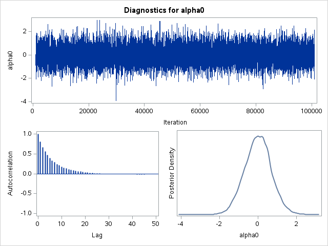

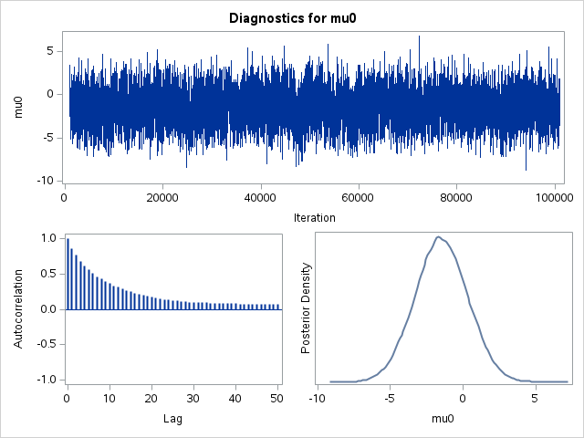

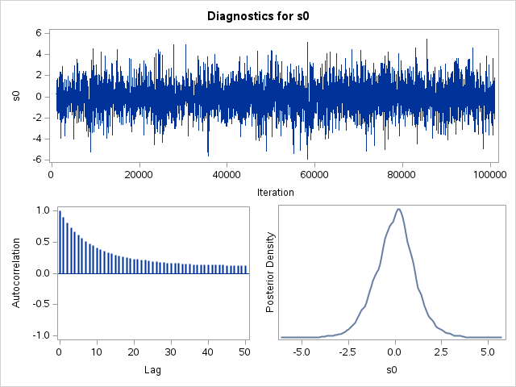

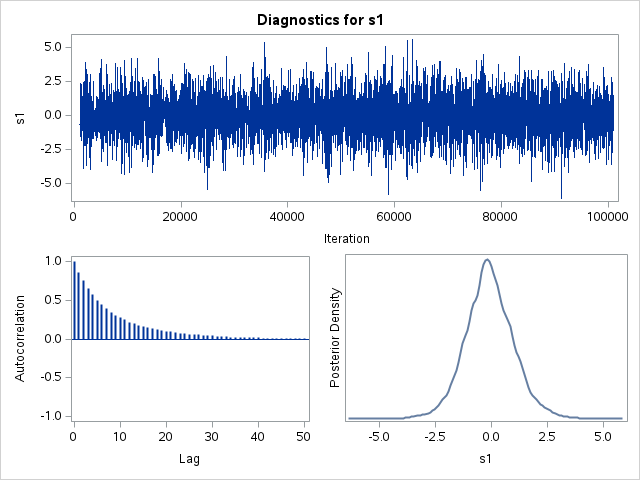

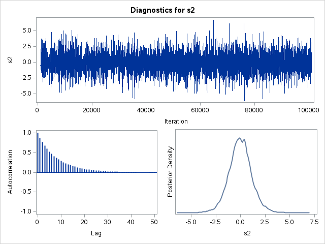

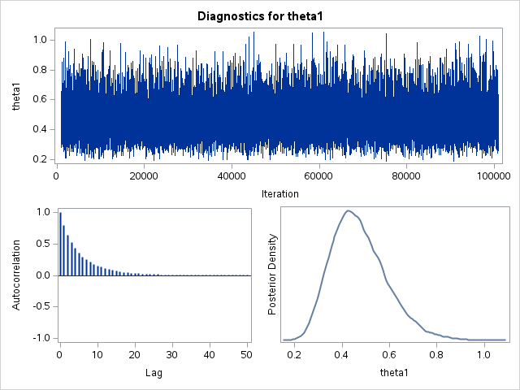

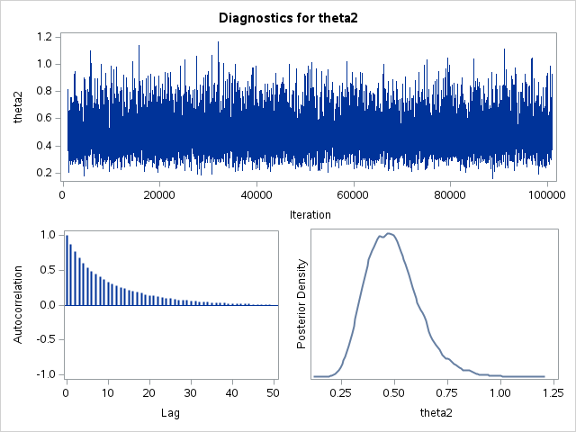

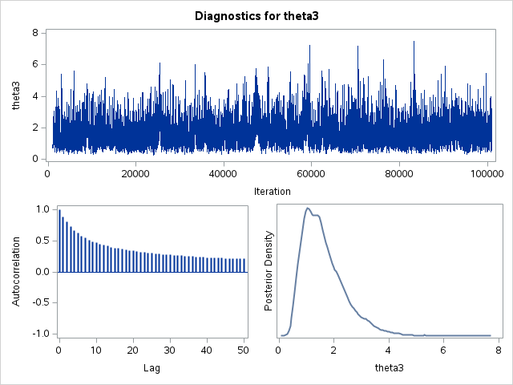

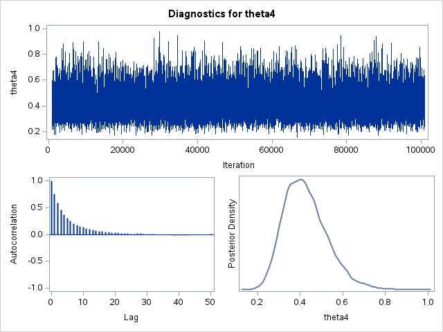

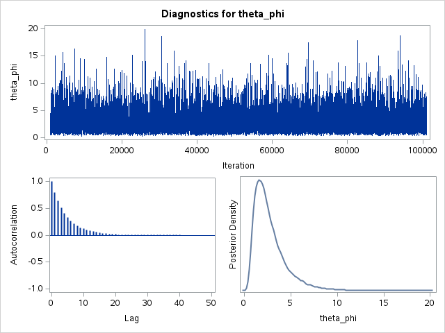

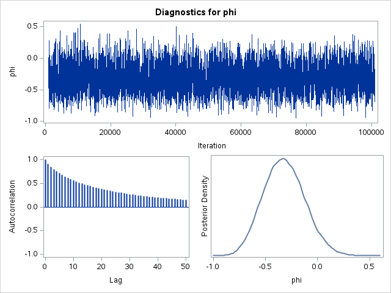

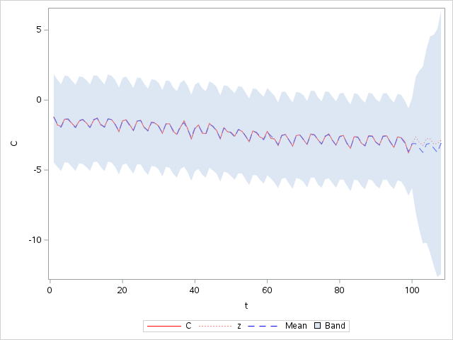

The CONTENTS Procedure

| Data Set Name | WORK.POSTERIOR | Observations | 100000 |
| --- | --- | --- | --- |
| Member Type | DATA | Variables | 245 |
| Engine | V9 | Indexes | 0 |
| Created | 04/15/2025 14:24:43 | Observation Length | 1960 |
| Last Modified | 04/15/2025 14:24:43 | Deleted Observations | 0 |
| Protection |  | Compressed | NO |
| Data Set Type |  | Sorted | NO |
| Label |  |  |  |
| Data Representation | SOLARIS_X86_64, LINUX_X86_64, ALPHA_TRU64, LINUX_IA64, LINUX_POWER_64 |  |  |
| Encoding | utf-8 Unicode (UTF-8) |  |  |

[output not shown]

| Alphabetic List of Variables and Attributes # | Alphabetic List of Variables and Attributes Variable | Alphabetic List of Variables and Attributes Type | Alphabetic List of Variables and Attributes Len | Alphabetic List of Variables and Attributes Format | Alphabetic List of Variables and Attributes Label |
| --- | --- | --- | --- | --- | --- |
| 233 | C_101 | Num | 8 | D8. |  |
| 234 | C_102 | Num | 8 | D8. |  |
| 235 | C_103 | Num | 8 | D8. |  |
| 236 | C_104 | Num | 8 | D8. |  |
| 237 | C_105 | Num | 8 | D8. |  |
| 238 | C_106 | Num | 8 | D8. |  |
| 239 | C_107 | Num | 8 | D8. |  |
| 240 | C_108 | Num | 8 | D8. |  |
| 1 | Iteration | Num | 8 | 8. |  |
| 244 | LogLike | Num | 8 | D8. | Log-Likelihood Value |
| 243 | LogMiss | Num | 8 | D8. | Log Density for Missing Values |
| 245 | LogPost | Num | 8 | D8. | Log Posterior Density |
| 241 | LogPrior | Num | 8 | D8. | Log Prior Density |
| 242 | LogReff | Num | 8 | D8. | Log Random-Effects Prior Density |
| 2 | alpha0 | Num | 8 | D8. |  |
| 13 | alpha_1 | Num | 8 | D8. |  |
| 14 | alpha_2 | Num | 8 | D8. |  |
| 15 | alpha_3 | Num | 8 | D8. |  |
| 16 | alpha_4 | Num | 8 | D8. |  |
| 17 | alpha_5 | Num | 8 | D8. |  |
| 18 | alpha_6 | Num | 8 | D8. |  |
| 19 | alpha_7 | Num | 8 | D8. |  |
| 20 | alpha_8 | Num | 8 | D8. |  |
| 21 | alpha_9 | Num | 8 | D8. |  |
| 22 | alpha_10 | Num | 8 | D8. |  |
| 23 | alpha_11 | Num | 8 | D8. |  |
| 24 | alpha_12 | Num | 8 | D8. |  |
| 25 | alpha_13 | Num | 8 | D8. |  |
| 26 | alpha_14 | Num | 8 | D8. |  |
| 27 | alpha_15 | Num | 8 | D8. |  |

[output cut: 215 more lines]

```sas
*Dynamic Linear Model;

proc mcmc data=UKcoal nmc=100000 seed=123456 outpost=posterior propcov=quanew;
  parms alpha0;
  parms mu0;
  parms s0 s1 s2;
  parms theta1;
  parms theta2;
  parms theta3;
  parms theta4;
  parms theta_phi;
  parms phi;
  prior phi~normal(0,var=exp(theta_phi));
  prior alpha0~normal(0,var=theta2);
  prior mu0~normal(0,var=100);
  prior s:~normal(0,var=theta3);
  prior theta:~igamma(shape = 3/10, scale = 10/3);
  random alpha~normal(phi*alpha.l1,var=exp(theta2)) subject=t icond=(alpha0);
  random s~normal(-s.l1-s.l2-s.l3,var=exp(theta3)) subject=quarter icond=(s2 s1 s0);
  random mu~normal(mu.l1 + alpha.l1,var=exp(theta1)) subject=t icond=(mu0);
  x=mu + s;
  model c~normal(x,var=exp(theta4));
  preddist outpred=TVCoutpred statistics=brief;
  ods output PredSumInt=TVCPredSumInt;
run;


data forecast;
  merge UKcoal TVCPredSumInt;
run;

proc sgplot data=forecast;
  series x=t y=c / lineattrs=(color=red);
  series x=t y=z / lineattrs=(color=red pattern=dot);
  series x=t y=mean / lineattrs=(color=blue pattern=dash);
  band x=t upper=hpdupper lower=hpdlower / transparency=.5;
run;

proc contents data=posterior;
run;
```

[figure not shown]